# Legalization of Cannabis and Its Healthcare and Workplace Consequences

# 1 Data Description

- We remove all the observations prior to October 2015.
- We also remove treated states that do not have at least $X = 1$ full year of data before or after legalization.

Here is a glimpse of the data:

```
## Rows: 3,741
## Columns: 79
## $ EGEOLOC               <fct> 04, 04, 04, 04, 04, 04, 04, 04, 04, 04, 04, 04, …
## $ YEAR                  <dbl> 2015, 2015, 2015, 2016, 2016, 2016, 2016, 2016, …
## $ month                 <dbl> 10, 11, 12, 1, 2, 3, 4, 5, 6, 7, 8, 9, 10, 11, 1…
## $ prev_oud              <dbl> 546.085, 498.553, 496.675, 469.644, 504.686, 557…
## $ prev_cud              <dbl> 85.517, 99.874, 122.931, 119.767, 143.014, 172.4…
## $ AUD                   <dbl> 460.569, 343.420, 365.493, 354.589, 427.467, 481…
## $ prev_mhd              <dbl> 10382.952, 9614.952, 9963.616, 9840.140, 9927.07…
## $ er_oud                <dbl> 142.121, 109.289, 90.342, 63.221, 68.552, 78.313…
## $ er_cud                <dbl> 30.949, 31.108, 42.490, 34.556, 34.276, 42.321, …
## $ er_aud                <dbl> 126.239, 86.367, 89.104, 111.128, 135.529, 161.3…
## $ er_mhd                <dbl> 777.388, 667.603, 648.483, 626.323, 695.766, 803…
## $ ip_adm_oud            <dbl> 17.103, 12.689, 6.600, 7.854, 11.031, 16.612, 9.…
## $ ip_adm_cud            <dbl> 5.294, 5.730, 5.363, 3.927, 4.334, 7.910, 5.956,…
```

[output cut: 66 more lines]

# 2 Descriptive Analyses

**List of control states:**

```
##  [1] "Alabama"        "Arkansas"       "Connecticut"    "Delaware"
##  [5] "Florida"        "Georgia"        "Hawaii"         "Idaho"
##  [9] "Illinois"       "Indiana"        "Iowa"           "Kansas"
## [13] "Kentucky"       "Louisiana"      "Maryland"       "Minnesota"
## [17] "Mississippi"    "Missouri"       "Nebraska"       "New Hampshire"
## [21] "New Mexico"     "New York"       "North Carolina" "North Dakota"
## [25] "Ohio"           "Oklahoma"       "Pennsylvania"   "South Carolina"
## [29] "South Dakota"   "Tennessee"      "Texas"          "Utah"
## [33] "Virginia"       "West Virginia"  "Wisconsin"      "Wyoming"
```

**List of treatment states:**

```
## [1] "Arizona"       "California"    "Maine"         "Massachusetts"
## [5] "Michigan"      "Montana"       "Nevada"
```

The following figure shows the cumulative number of states that legalized the recreational use of cannabis over time.

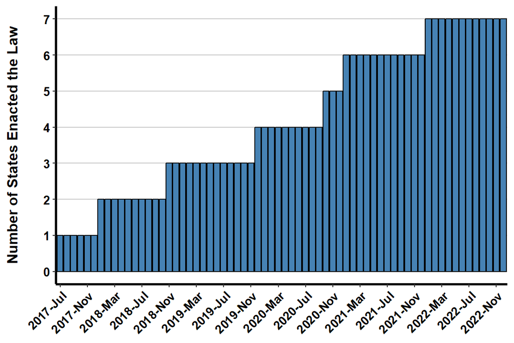

The following figure demonstrates the trend of state-level average number of annual enrollees in the states that enacted the cannabis laws (`treatment`) and other states (`control`):

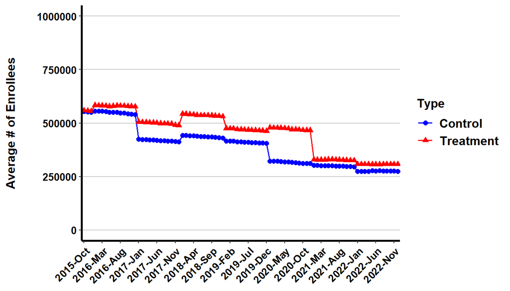

Next, we explore how the legalization of the recreational use of cannabis impacted the healthcare and operational outcomes in states. For each outcome, we first explore the trend of average total values and rate of outcomes in the states that enacted the cannabis laws (treatment) and other states (control). Next, we explore the trend of the number and rate of outcome in the treatment states before and after the legalization.

## 2.1 Outcomes related to CUD

The measure of interest is the prevalence of each outcome (i.e., number of unique patients who are diagnosed with that outcome for each state/year/month).

### 2.1.1 Prevalence

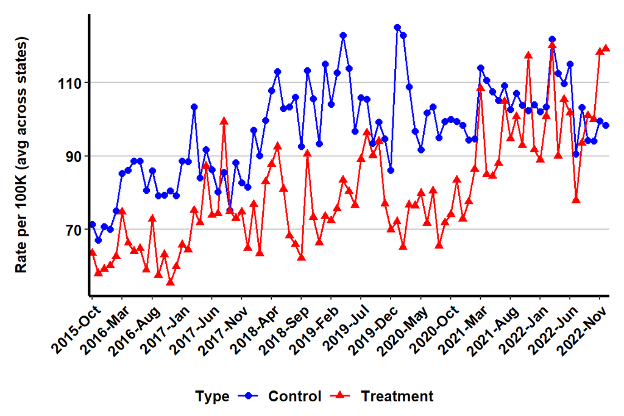

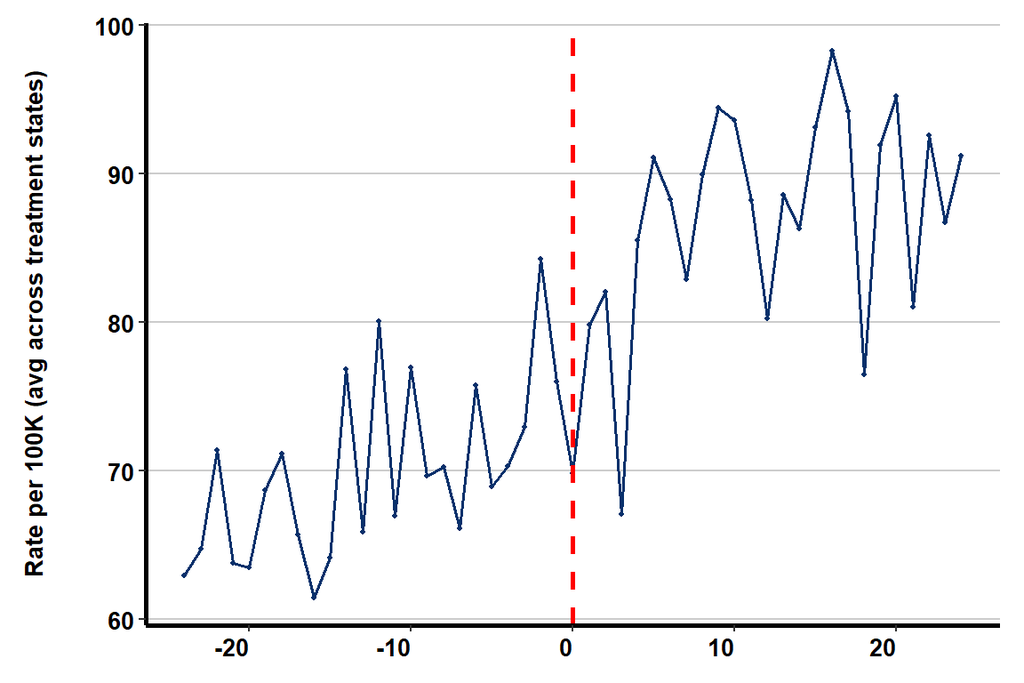

### 2.1.2 IP Admissions

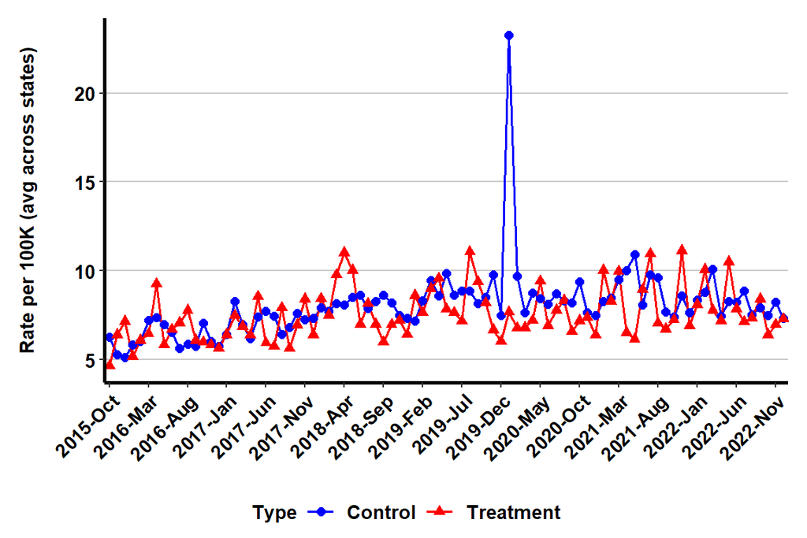

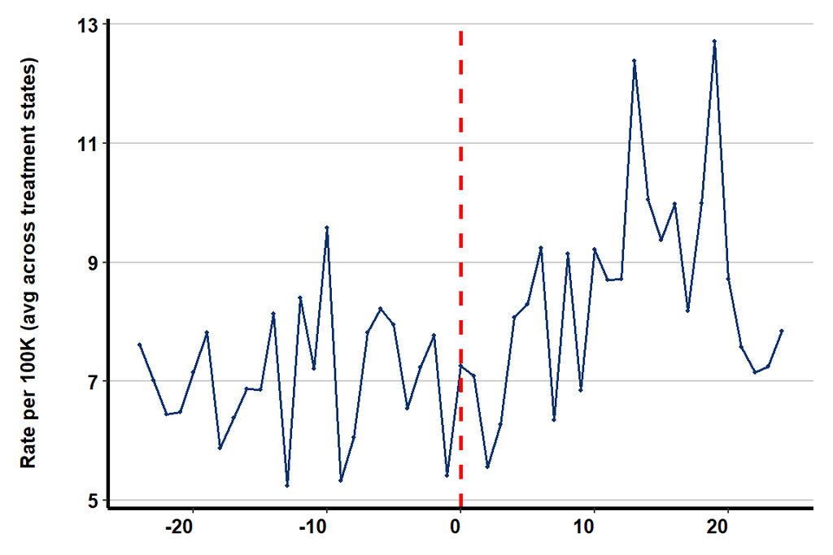

### 2.1.3 Length of Stay (LOS)

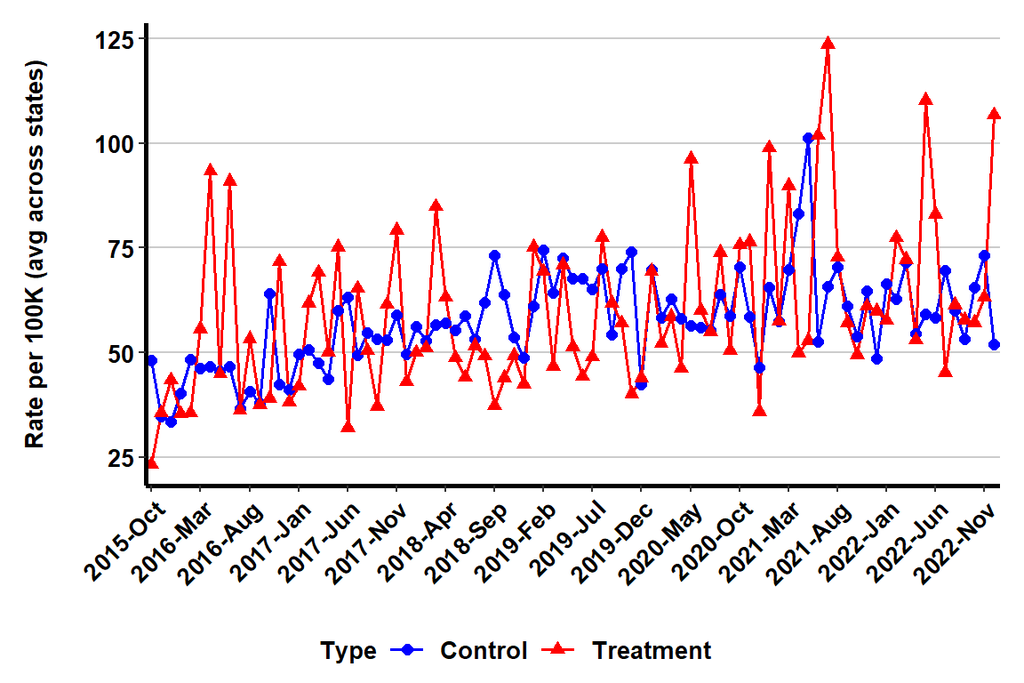

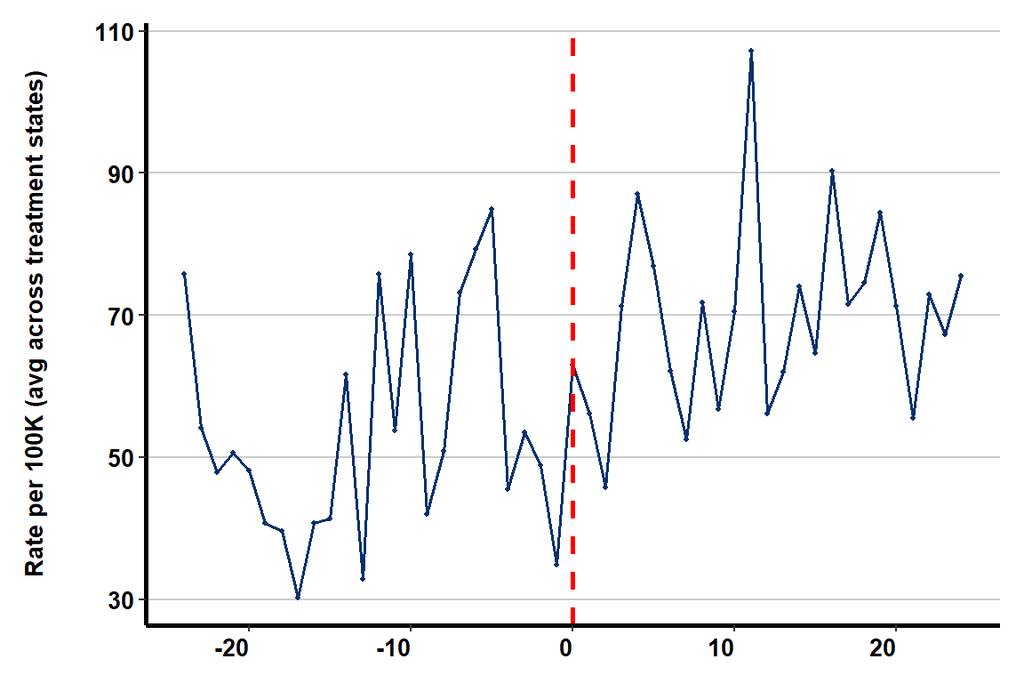

### 2.1.4 ER Visits

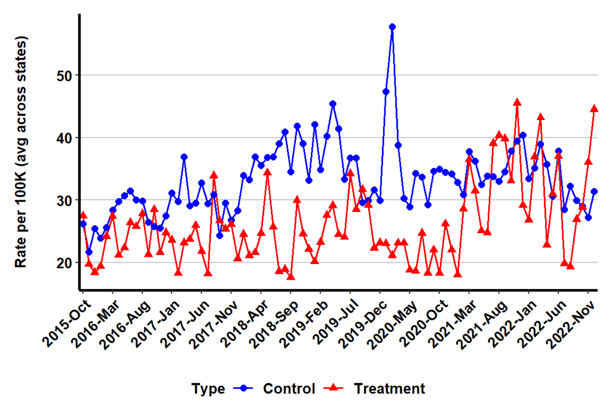

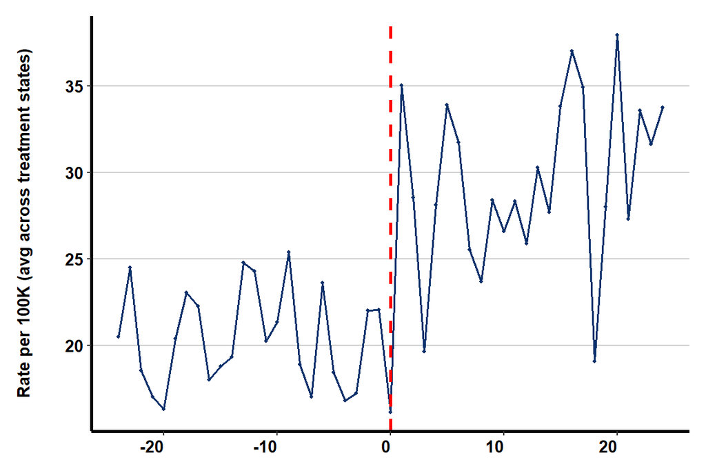

### 2.1.5 Total Payments

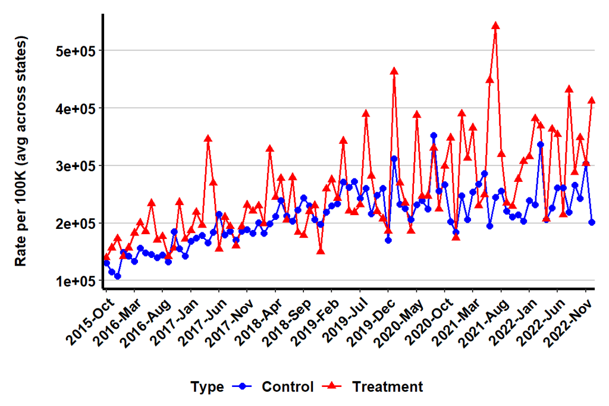

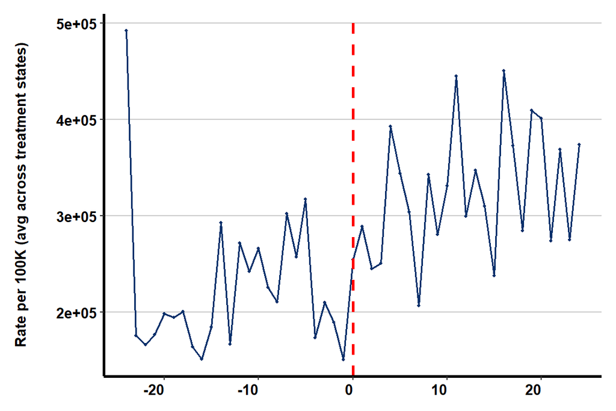

## 2.2 Outcomes related to OUD

### 2.2.1 Prevalence

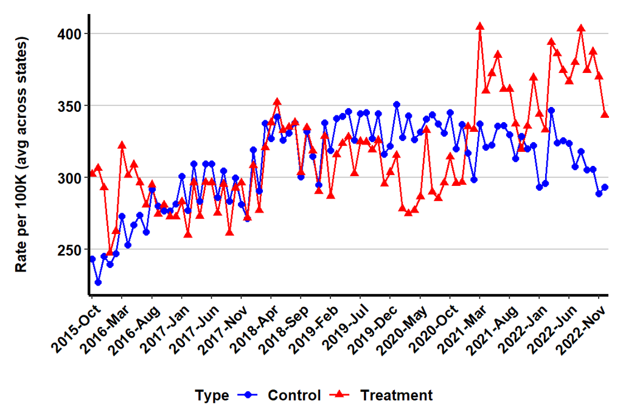

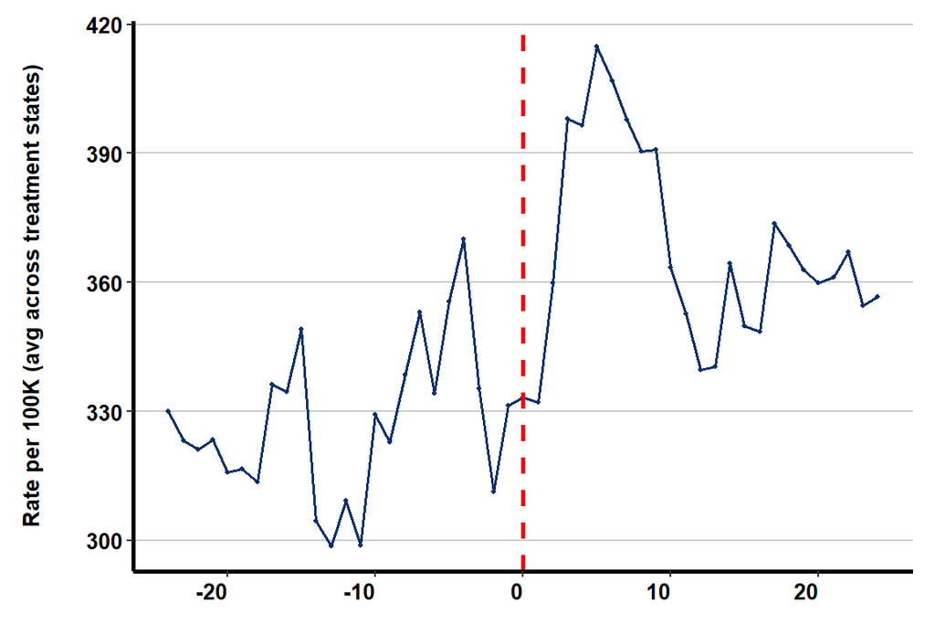

### 2.2.2 IP Admissions

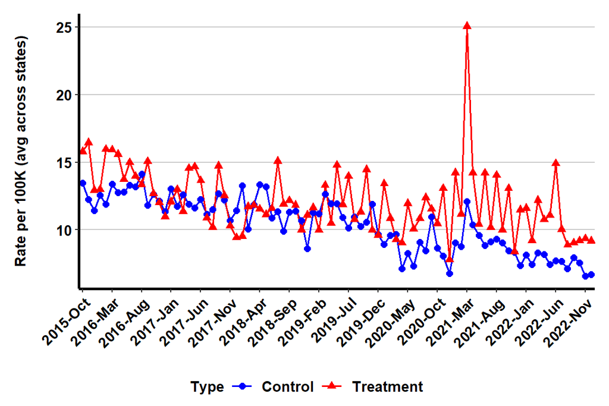

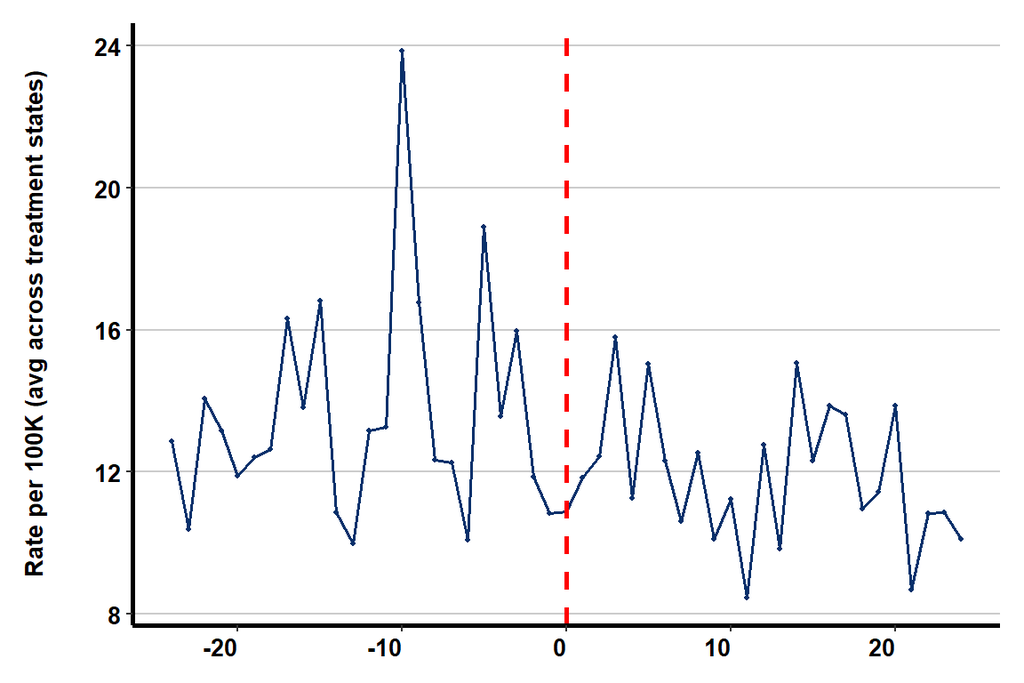

### 2.2.3 Length of Stay (LOS)

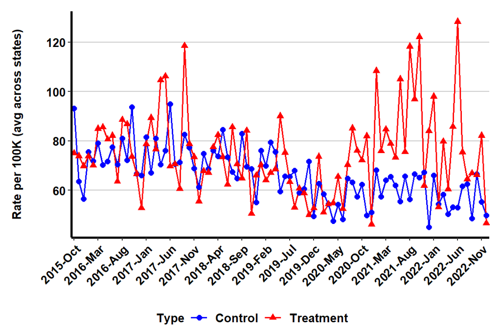

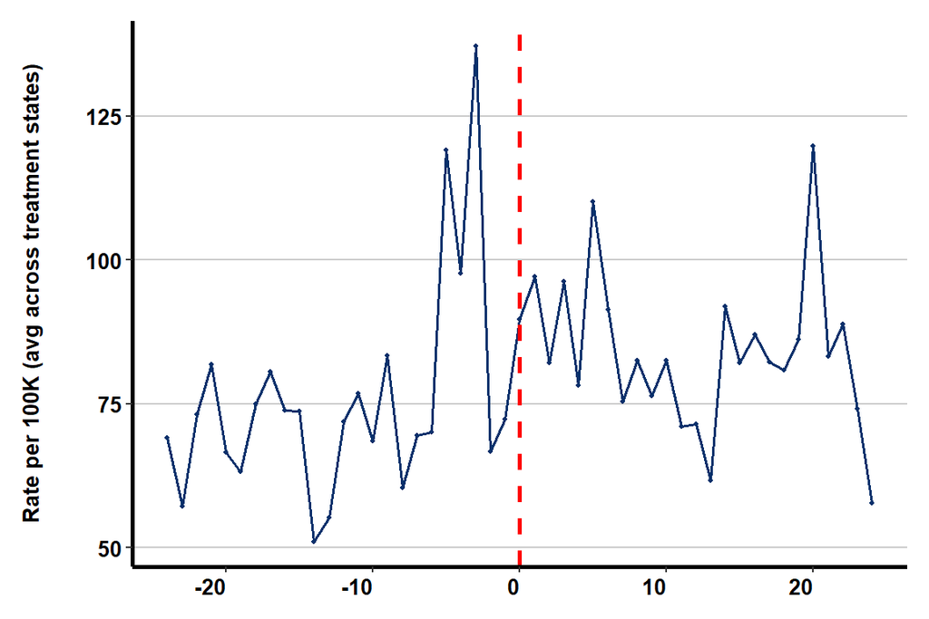

### 2.2.4 ER Visits

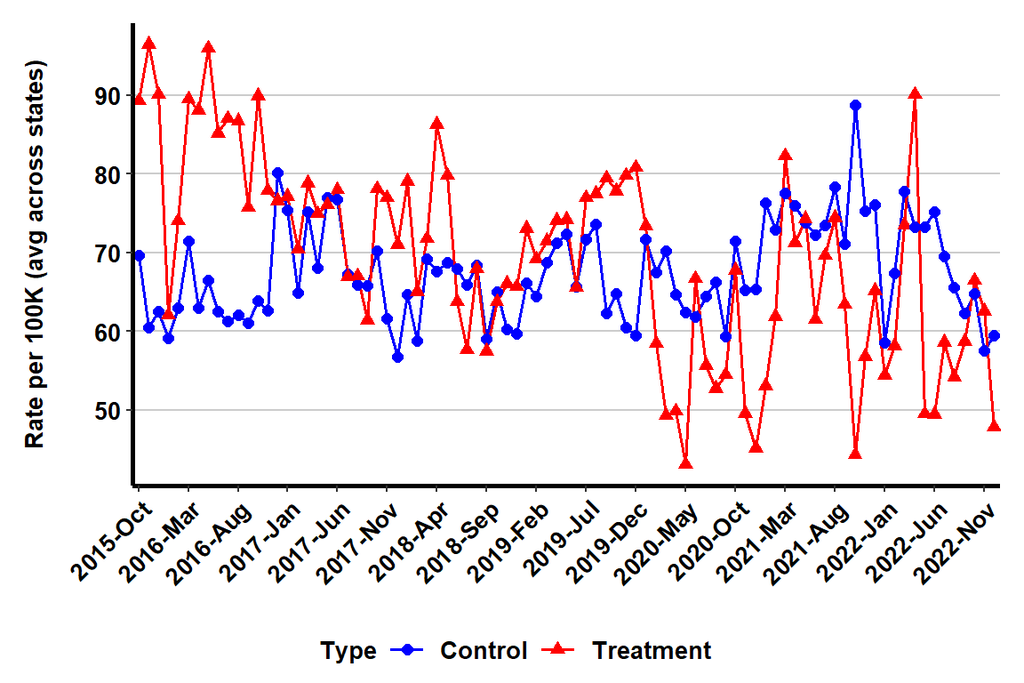

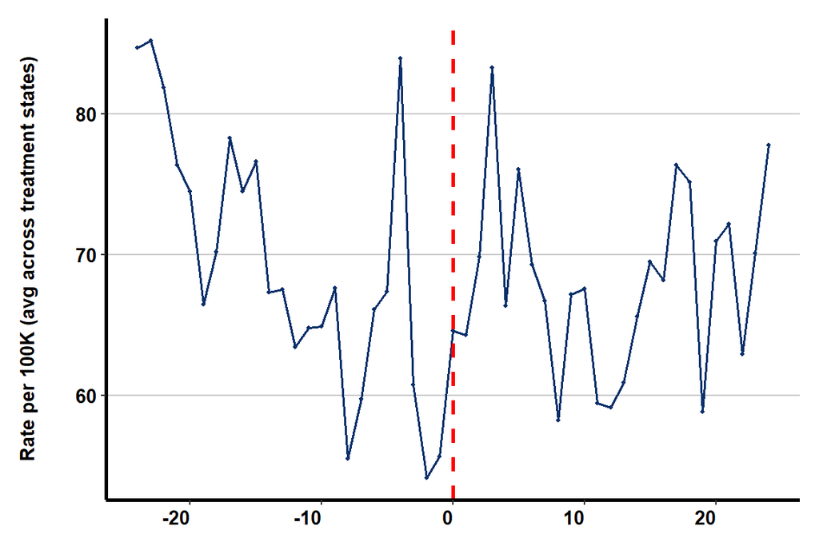

### 2.2.5 Total Payments

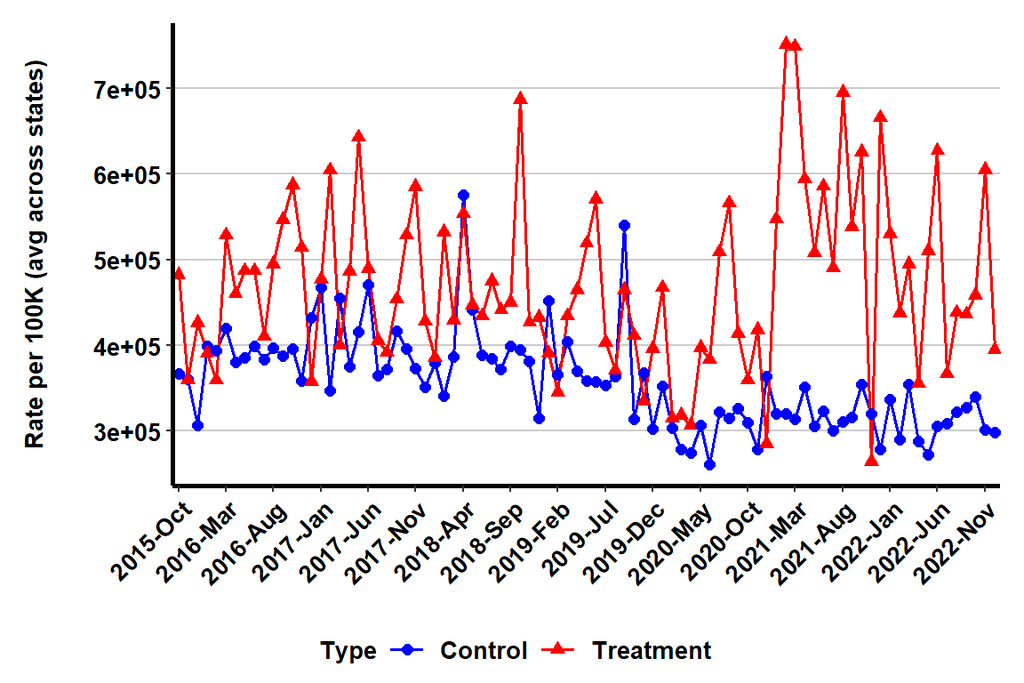

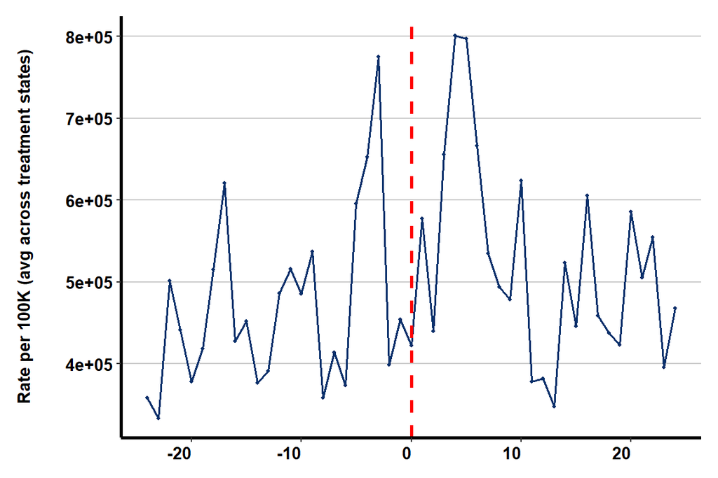

## 2.3 Outcomes related to Prescriptions

### 2.3.1 Opioids: Total Days of Supply

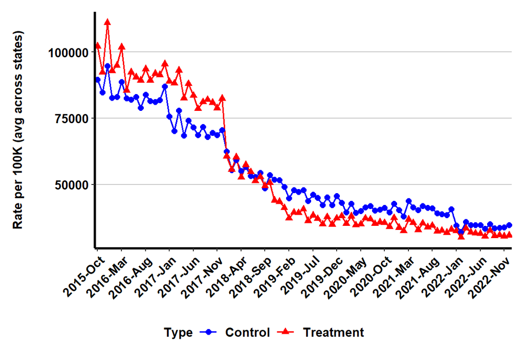

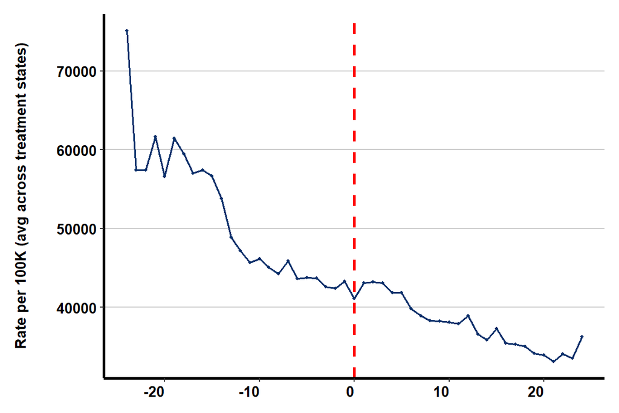

### 2.3.2 Opioids: Total Strength

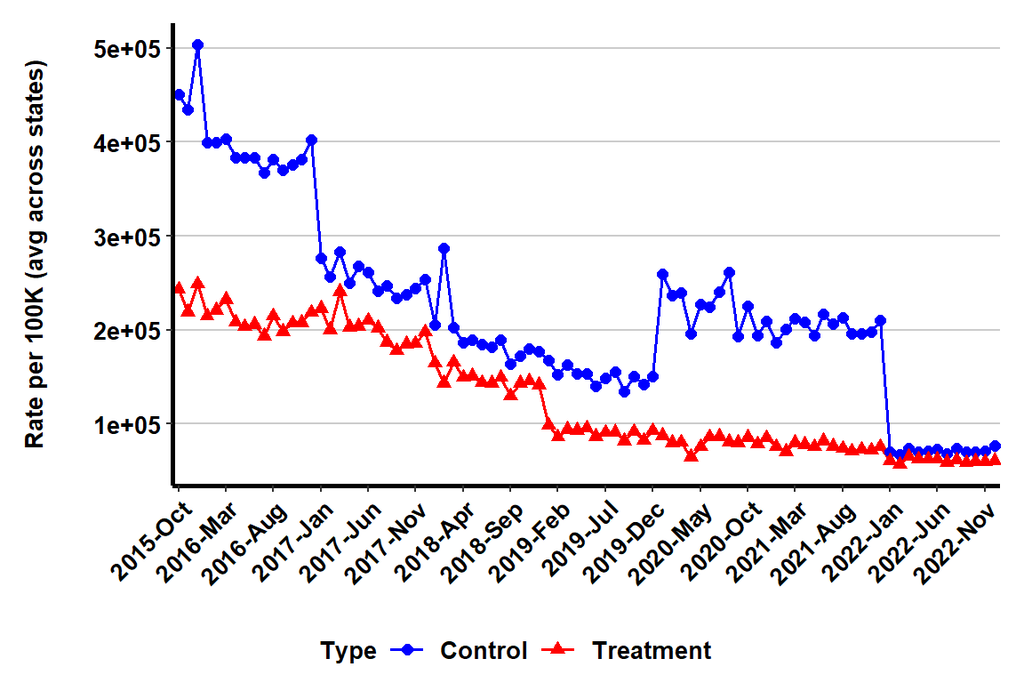

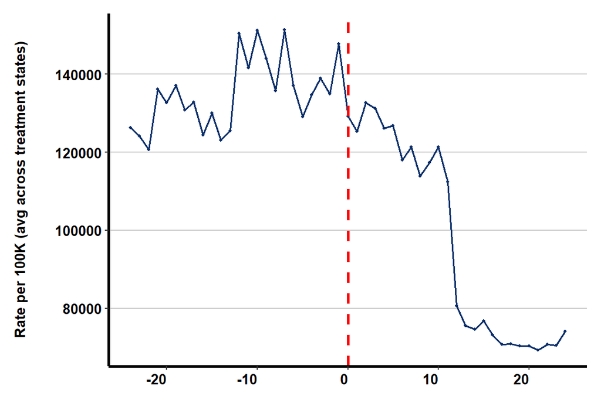

### 2.3.3 Opioids: Number

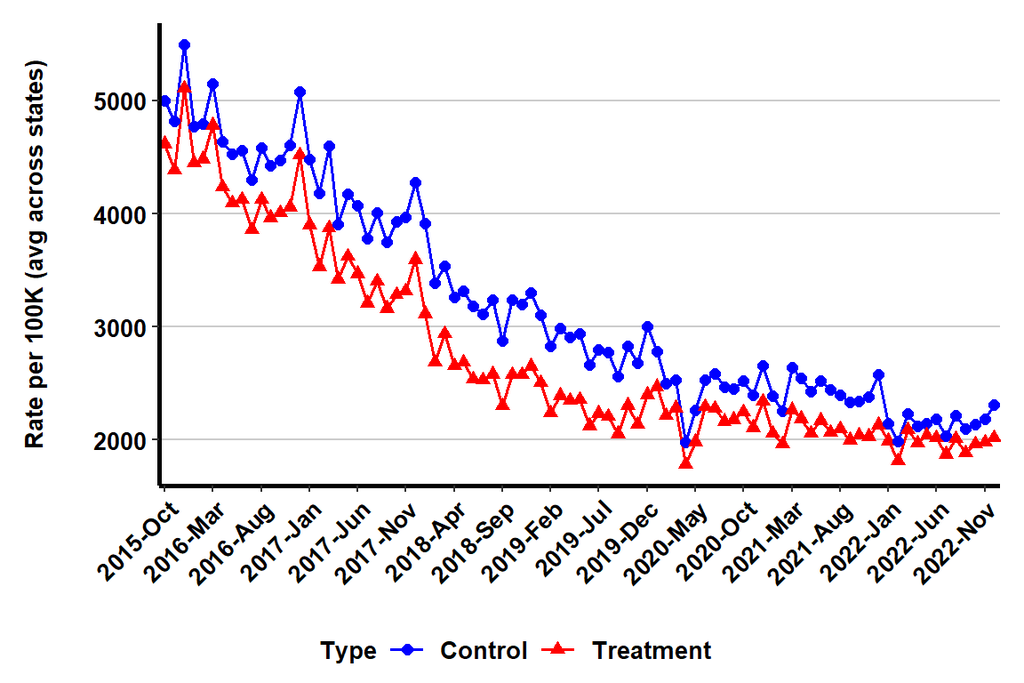

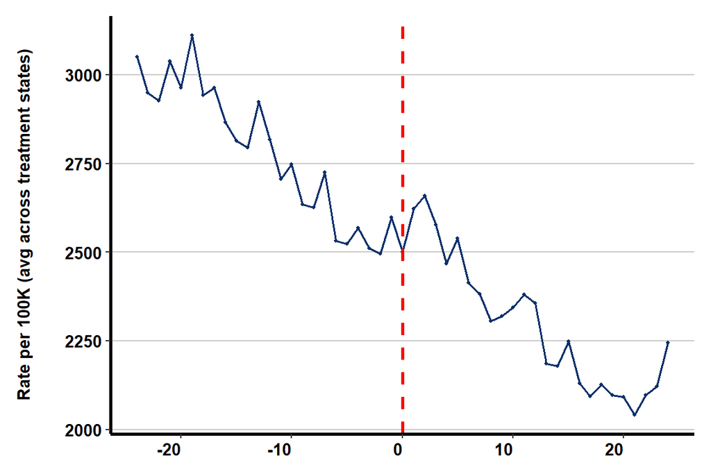

### 2.3.4 Opioids: Payment

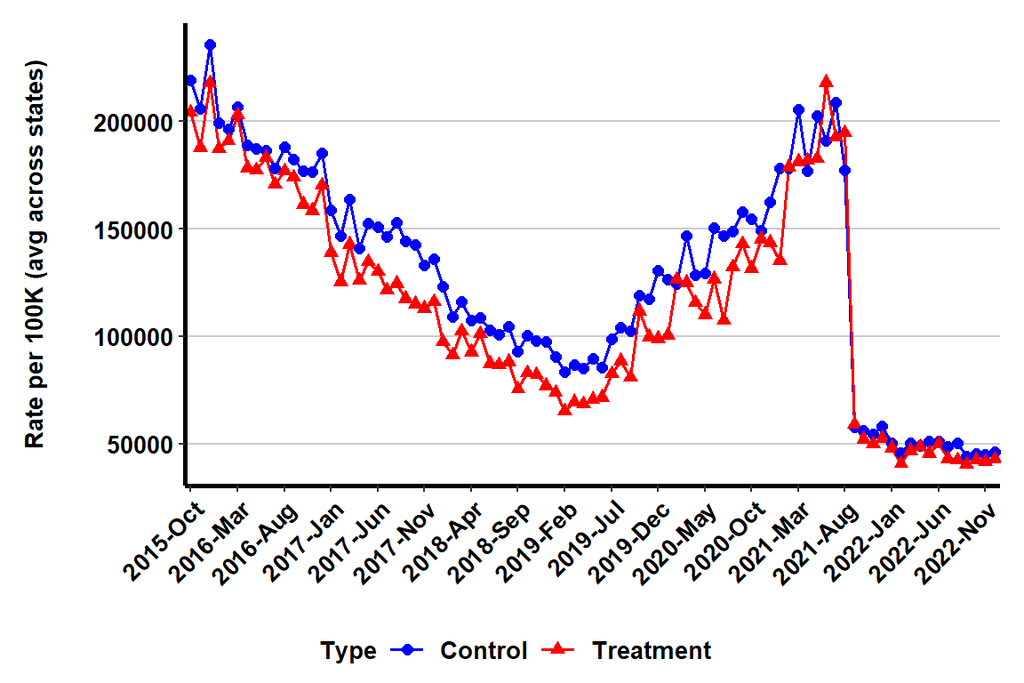

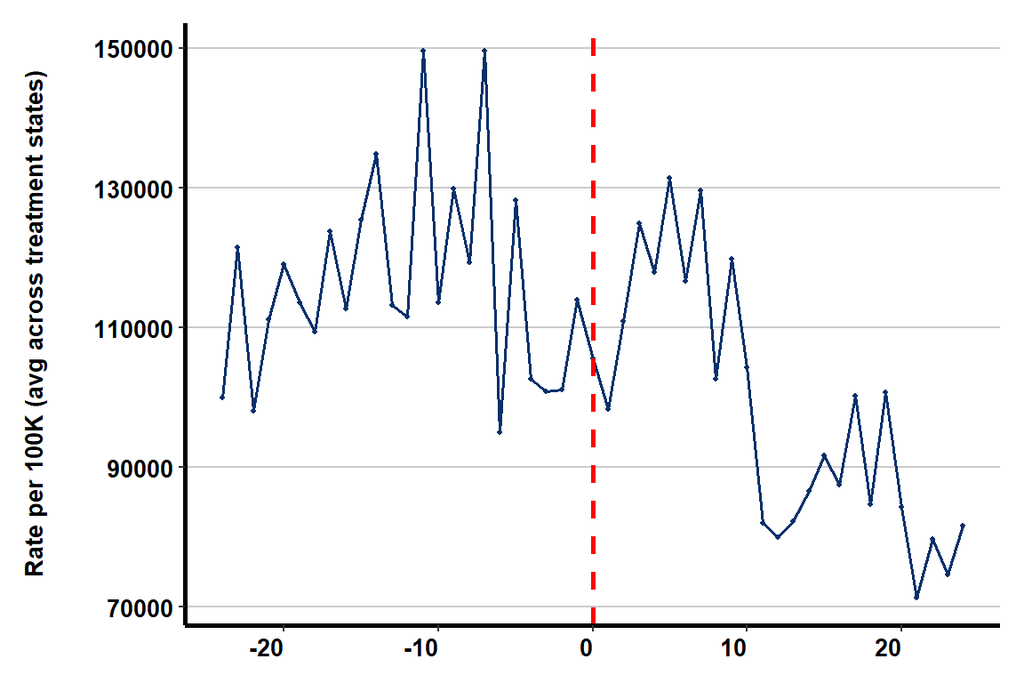

### 2.3.5 All Meds: Number

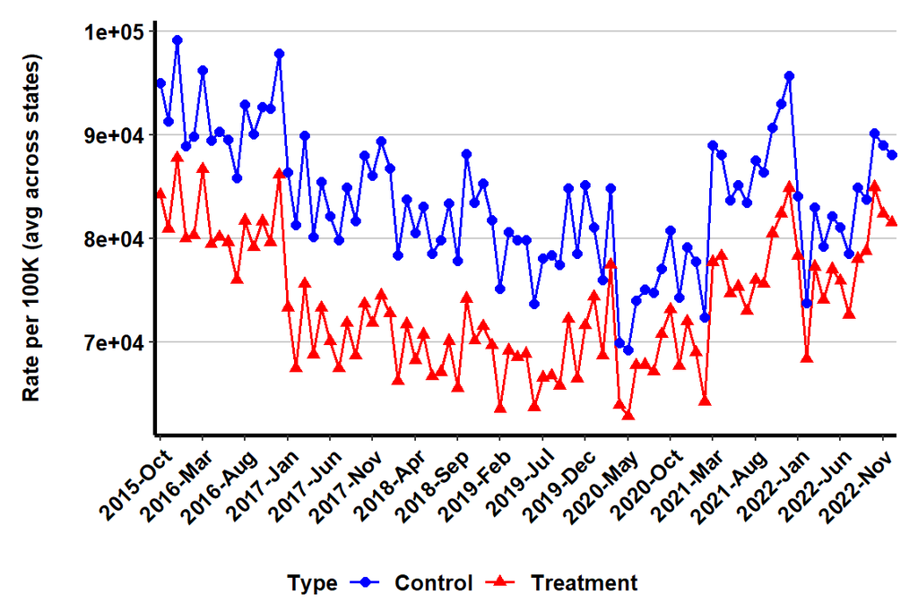

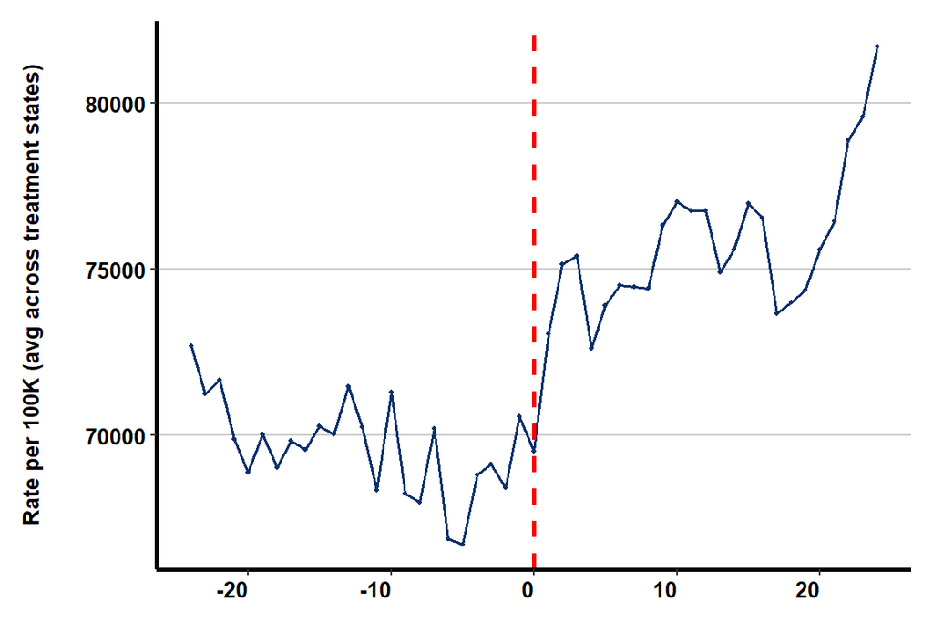